# How to create a scatterplot

Author

Patrice Lewis and Julissa Martinez

Published

May 3, 2024

## Introduction

Scatterplots display the relationship between two variables using dots to represent the values for each numeric variable. This presentation will examine the relationship between `GDP per capita` and `Fertility` over time using ggplot with facets.

**Hypothesis:** A negative relationship exists between GDP per capita and fertility i.e. as GDP per capita increases, fertility decreases.

## Data

Data was obtained from GapMinder for each health and non-health indicator and combined into one data set. The data includes information on over 180 countries and territories from the years 1800 to 2099. Countries and territories with missing information were not excluded from the data set as the lack of information can also be looked into and shed light on why data was not collected or provided.

To determine whether a country’s health and income outcomes are influenced by population sizes and GDP per capita, the data will be used to create a series of graphs to view different trends. It is important to note certain analysis’ will only be done on specific countries and on certain years. Predictive values were provided up until 2099 however, we will focus on years with full and current data.

```r
# Contains colour palette for ggplot
library(viridis)

# Contains "gganimate"
library(ggplot2)
library(gganimate)

library(tidyverse)


# Reads csv file
gapminder_data <-
  # read_csv("clean_data/gapminder_scatterplot.csv")
  read_csv("../data/01_gapminder_2024spring.csv")
```

## How to create a scatter-plot

### Intro to ggplot2

Ggplot2 is a package used to create graphs and visualize data. The main three components of ggplot2 are the data, aesthetics and geom layers.

- The data layer - states what data will be used to graph
- The aesthetics layer - specifies the variables that are being mapped
- The geom layer - specifies the type of graph to be produced

### Basic scatter-plot using ggplot2

In order to create a scatter-plot using ggplot, you must specify what data you will be using, state which variables will be mapped and how under aesthetics. What differentiates the scatter-plot from any other type of graph will be specified under the geom layer. For the scatter-plot, geom_point will be used.

In this example, we will analyze the relationship between fertility rates and gdp per capita for each country in 2011.

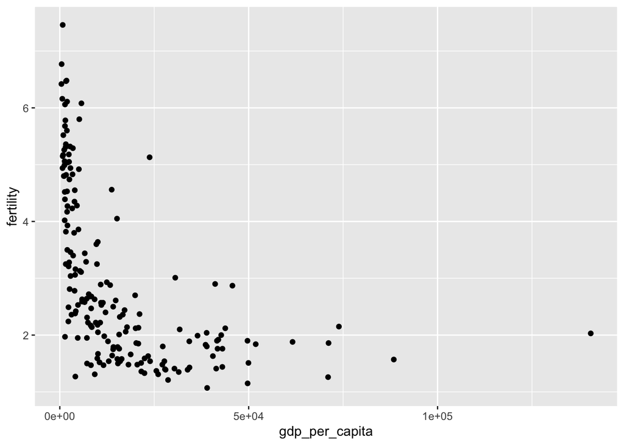

```r
fig_bubble_2011 <-
  ggplot(data = filter(gapminder_data, year == 2011)) +
  aes(x = gdp_per_capita, y = fertility) +
  geom_point()

fig_bubble_2011
```

### Elevating your scatter-plot

In the example above, we have mapped out fertility as our y-axis and gdp per capita as our x-axis. However, at it’s very basic level, there is not enough information provided to accurately analyze the relationship between the two. For this reason, we can add additional layers that will provide more information to properly analyze the scatter-plot.

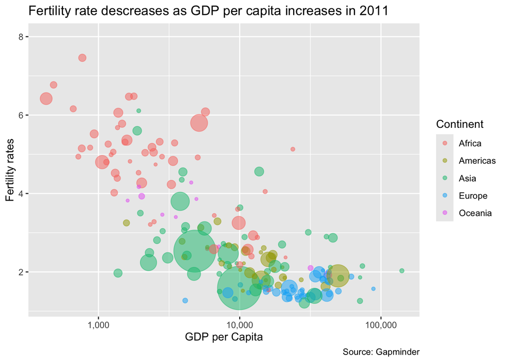

```r
fig_bubble_pretty_2011 <-
  ggplot(data = filter(gapminder_data, year == 2011)) +
  aes(
    x = gdp_per_capita,
    y = fertility,
    # will change the size of the point based on population size
    size = population,
    # will assign colors based on the continent the country is in
    color = continent
  ) +
  # gives a range as to how big or small the points of population should be
  scale_size(range = c(1, 20)) +
  # removes N/A from the legend and titles it Continent
  scale_colour_discrete(na.translate = F, name = "Continent") +
  # removes population size from the legend
  guides(size = "none") +
  scale_x_continuous(
    name = "GDP per Capita",
    trans = "log10",
    # transforms numbers from scientific notation to regular number
    labels = scales::comma
  ) +
  labs(
    title = "Fertility rate descreases as GDP per capita increases in 2011",
    y = "Fertility rates",
    caption = "Source: Gapminder"
  ) +
  # the ylim was set based on the fertility, lowest was 1.15 & highest was 7.25
  ylim(1.2, 8.0) +
  # alpha increases transparency of the points to ensure they can all be seen
  geom_point(alpha = 0.5)

fig_bubble_pretty_2011
```

### Facets

Here is an example of wanting to create four separate graphs to see the relationship between fertility rates and GDP per capita based on the years 1860, 1910, 1960 and 2010. In this example we omitted the facet argument.

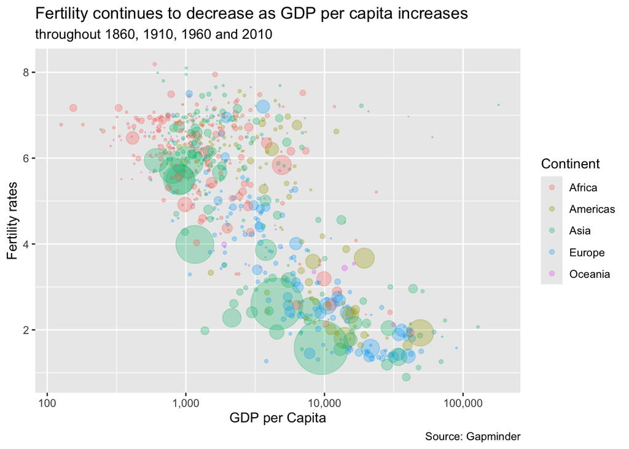

```r
fig_bubble_multiple <-
  ggplot(data = filter(gapminder_data, year %in% c(1860, 1910, 1960, 2010))) +
  aes(
    x = gdp_per_capita,
    y = fertility,
    size = population,
    color = continent
  ) +
  scale_x_continuous(
    name = "GDP per Capita",
    trans = "log10",
    labels = scales::comma
  ) +
  scale_size(range = c(0, 20)) +
  guides(size = "none") +
  scale_colour_discrete(na.translate = FALSE, name = "Continent") +
  labs(
    title = "Fertility continues to decrease as GDP per capita increases",
    subtitle = "throughout 1860, 1910, 1960 and 2010",
    caption = "Source: Gapminder",
    y = "Fertility rates"
  ) +
  geom_point(alpha = 0.3)

fig_bubble_multiple
```

Without having used the facet argument, all points of all four years have been included into one graph. This graph does not provide us with the information we were looking for.

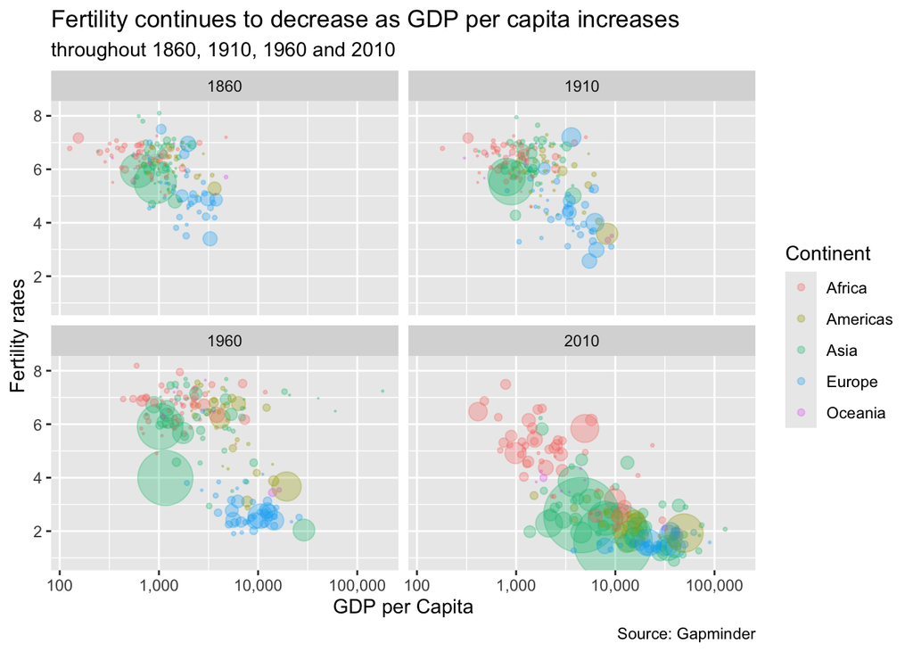

```r
fig_bubble_multiple_facet <-
  ggplot(data = filter(gapminder_data, year %in% c(1860, 1910, 1960, 2010))) +
  aes(
    x = gdp_per_capita,
    y = fertility,
    size = population,
    color = continent
  ) +
  scale_x_continuous(
    name = "GDP per Capita",
    trans = "log10",
    labels = scales::comma
  ) +
  scale_size(range = c(0, 20)) +
  guides(size = "none") +
  scale_colour_discrete(na.translate = FALSE , name = "Continent") +
  labs(
    title = "Fertility continues to decrease as GDP per capita increases",
    subtitle = "throughout 1860, 1910, 1960 and 2010",
    caption = "Source: Gapminder",
    y = "Fertility rates"
  ) +
  geom_point(alpha = 0.3) +
  # specifiying we want the graphs split based on year
  facet_wrap(~ year)

fig_bubble_multiple_facet
```

This global trend can be attributed to the increasing proportion of women in the workforce in the mid to late 20th century. As a result of World War II (1939-1945), women took on roles outside the home to compensate for men at war. Despite increased GDP per capita, this may have contributed to reduced fertility (babies per woman) over time. During 1860 - 1910, the scatter-plot figures remained in the upper left quadrant with the numbers remaining between 2 - 8 babies per woman. In 1960, a clear disparity among continents is seen. Most European countries’ fertility rates fell below 5, while their GDP per capita increased. Most African countries maintained high fertility rates above 5, but little change is seen in GDP per capita. The Asian continent shows the most variation among countries during that year. Some smaller Asian countries continued to maintain high fertility rates as GDP per capita increased in 1960. However, others displayed a drastic decrease in fertility rates by 1960. The Americas followed a steady decline over the years. By 2010, an overall negative relationship can be seen with most countries’ fertility rates below 5 babies per woman.

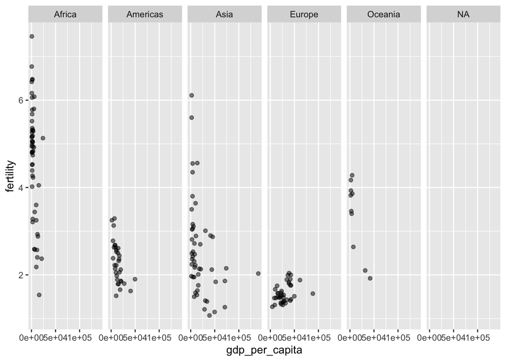

```r
fig_bubble_row_2011 <-
  ggplot(data = filter(gapminder_data, year == 2011)) +
  aes(
    x = gdp_per_capita,
    y = fertility
  ) +
  geom_point(alpha = 0.5) +
  facet_wrap(~ continent, nrow = 1)

fig_bubble_row_2011
```

In the graph above, we see an example of seperating the single graph into graphs based on continent. It has also been specified to have all graphs appear in one single row through the nrow argument. However, this graph is also unclear and cannot be used to compare the relationship between fertility and gdp per capita.

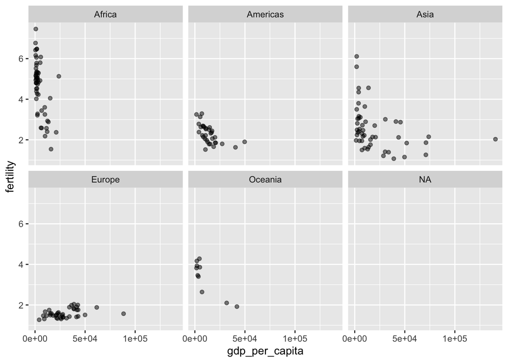

```r
fig_bubble_facet_2011 <-
  ggplot(data = filter(gapminder_data, year == 2011)) +
  aes(
    x = gdp_per_capita,
    y = fertility
  ) +
  geom_point(alpha = 0.5) +
  facet_wrap(~ continent)

fig_bubble_facet_2011
```

In the next example above, we removed the nrow argument and the system automatically seperated the graphs into three columns with two rows. However, again, there is no way to clearly determine any relationship between fertility and gdp per capita.

## Scatterplot animation

GGplot2 contains the “gganimate” package that allows for animation of data. It enhances data visualization through real-time outputs. In this case the gapminder data will be filtered to 2011 and below (full data available).

```r
gapminder_df <-
  gapminder_data %>%
  # Excludes data beyond 2011 (last year with complete data)
  filter(year <= "2011")

fig_animate <-
  ggplot(gapminder_df) +
  aes(
    x = gdp_per_capita,
    y = fertility,
    size = population,
    color = continent
  ) +
  scale_x_continuous(
    name = "GDP per Capita",
    trans = "log10",
    labels = scales::comma
  ) +
  # Assigns color palette
  scale_color_viridis_d() +
  scale_size(range = c(0, 20)) +
  guides(size = "none") +
  geom_point(show.legend = TRUE, alpha = 0.7) +
  # Assigns the gganimate features
  transition_time(year) +
  ease_aes('linear', interval = 2.0) +
  # Prints time of current frame
  labs(title = "Year: {frame_time}", x = "GDP per capita", y = "Fertility")


fig_animate
```

[output not shown]

```r
facet_animate <-
  ggplot(gapminder_df) +
  aes(
    x = gdp_per_capita,
    y = fertility,
    size = population,
    colour = continent
  ) +
  scale_x_continuous(
    name = "GDP per Capita",
    trans = "log10",
    labels = scales::comma
  ) +
  scale_size(range = c(0, 20)) +
  guides(size = "none") +
  # Groups output by continents
  facet_wrap(~continent) +
  labs(
    title = 'Year: {closest_state}',
    x = 'GDP per capita',
    y = 'fertility'
  ) +
  geom_point(alpha = 0.7, show.legend = TRUE) +
  # Contains gganimate features
  transition_states(year, transition_length = 3, state_length = 1) +
  # Animation pattern, time between each state
  ease_aes('linear', interval = 2.0)

facet_animate
```

[output not shown]

## Conclusion

A global negative trend is depicted between `GDP per capita` and `fertility` over time. Such changes were due to wars as well as social, cultural and economic changes that incentivize smaller families especially in Asian countries. Most European, American and Asian countries depicted significant decreases in fertility rates over time as `GDP per capita` increased. On the other hand, African countries remain in the top rank for fertility over the years. These differences are depicted in the population pyramid changes of developed vs developing countries. Public health policies can be tailored to incentivizing increased fertility in developed countries to ensure generation continuity, and effective family planning strategies in developing countries.